# Exploring_LUR_Data

Sheena Martenies

2/12/2020

## Objectives

The purpose of this script is to explore the LUR dataset and determine how we want to proceed with model development. In a meeting with Zev Ross on Feb 4, 2020, we discussed the following issues with the dataset:

- Temporal resolution
  - We have weekly (roughly) data for our sampling locations, and our original thought was to aggregate to months
  - However, we are missing some months and have sparse data for others (i.e., one week of data represents the whole month)
  - Does a monthly model make sense if we have finer temporal data? We’d like to use the most temporally refined model possible
- Spatial patterns over time
  - Part of the challenge is that we do not yet know if spatial patterns remain the same over time
  - Previous studies using hind-casted LUR have assumed that spatial patterns don’t change over time and use a single point (i.e., a monitor) to raise and lower a surface.
  - We need to understand if this is something that can be done in Denver
- Variable selection
  - The LASSO-to-Stepwise AIC approach was not a favorite of Zev’s.
  - He was concerned that the AIC methods were not appropriate, given that they don’t consider how one variable affects others in the model
  - The LASSO search window is too broad, and needs to be tightened
  - Move forward with a LASSO approach with better initial parameters
  - Also, CV needs to be a part of the variable selection process, not something that occurs after the fact
  - We need to incorporate leave-location-out CV (think CAST package)
- Incorporating time into the prediction model
  - Time is an interesting challenge here
  - We have repeated measures at our locations
  - One option is to use a GAM with smoothing terms for time (e.g., julian day or week no.)
  - More thought is needed here to make sure we’re doing things correctly.

This meeting resulted in a list of to-do’s for exploring our data. This script achieves the following:

- Generates time-series plots of the LUR outcome variables and key spatiotemporal predictors
- Maps the long-term averages at each location and creates an average surface using IDW
- visualizes relationships between BC and the spatiotemporal predictors (BC at the near-road monitor, temperature, BC)
- Maps average surfaces (IDW) for each month to assess whether spatial patterns are consistent across the year

Overall findings of this analysis include:

- The relationships between filter BC and monitor BC, PM2.5, and temperature are not linear
- There appears to be both temporal and spatial variability in BC measured across the study area
- Some months look similar in spatial patterns (e.g., July and August look simiar) but there are definitely differences

### A) Time series plots of BC and key spatiotemporal predictors

1. Starting with overall weekly and monthly means of BC across the entire study area

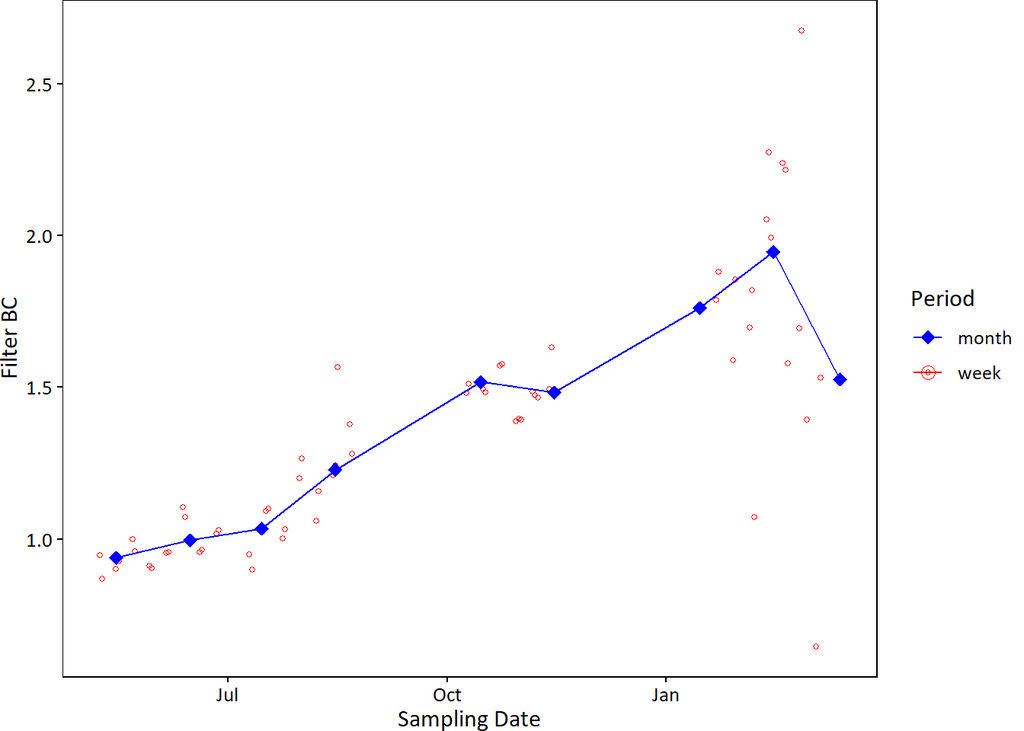

2. Temporal trends in BC at each unique sampling location (weekly TWAs)

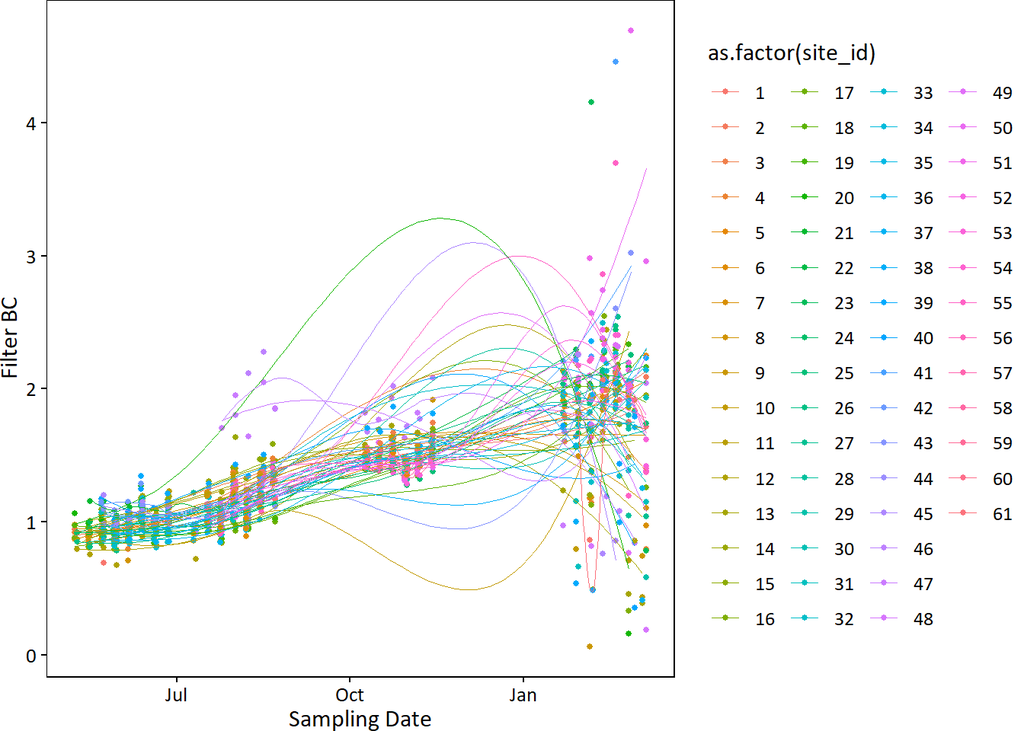

3. Temporal trends in monitor BC, PM, and temperature averaged across the entire study area

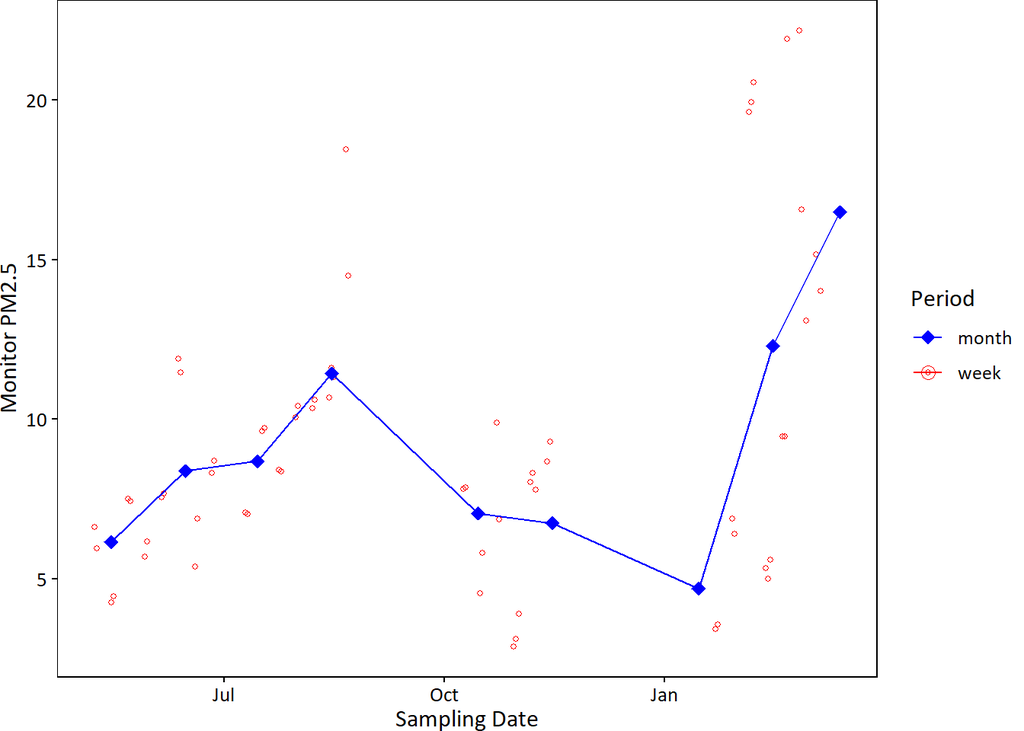

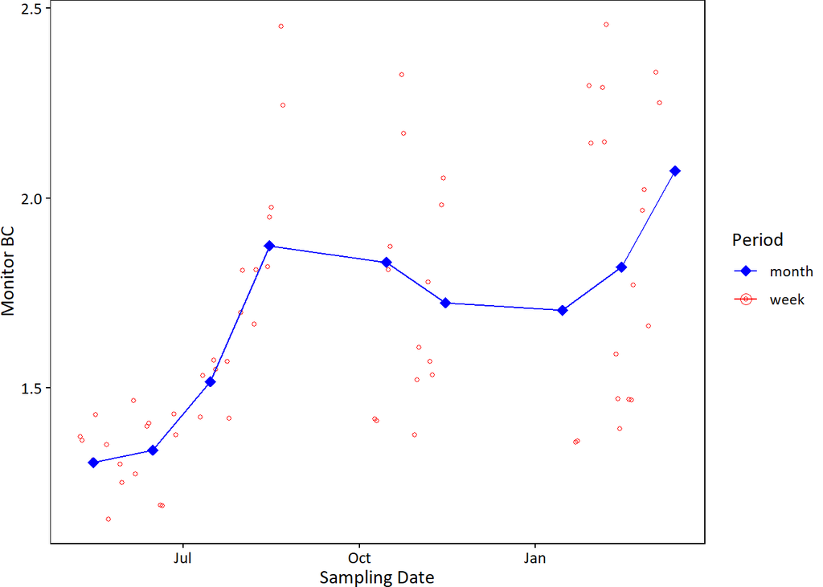

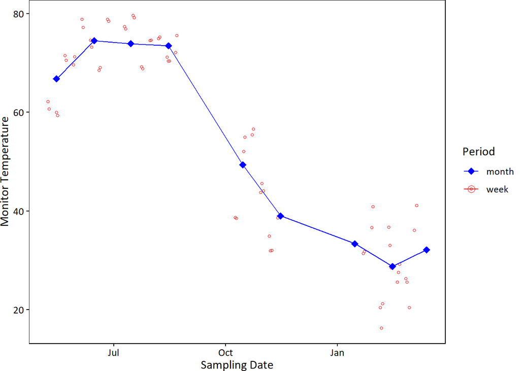

### B) Relationships between BC and spatiotemporal predictors averaged across the entire study period for each sampling locaton

1. Site BC and monitor BC

The correlation coefficient for average site BC to average monitor BC is 0.81.

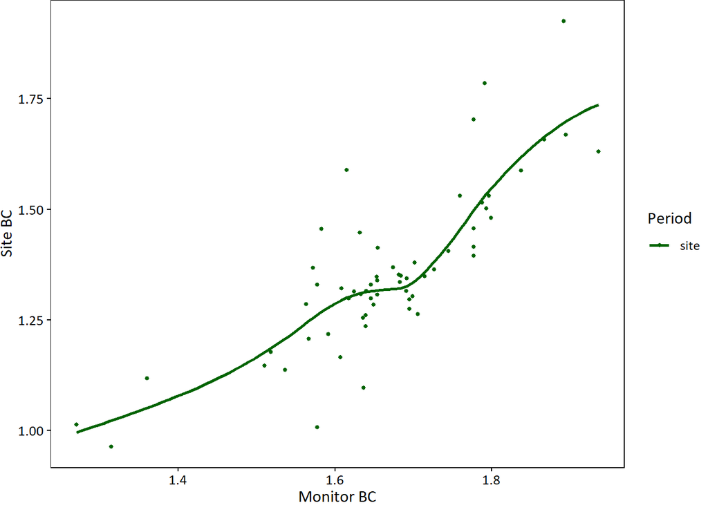

2. Site BC and monitor PM (mean of closest 3 monitors to the sampling location)

The correlation coefficient for average site BC to average monitor PM2.5 is 0.26.

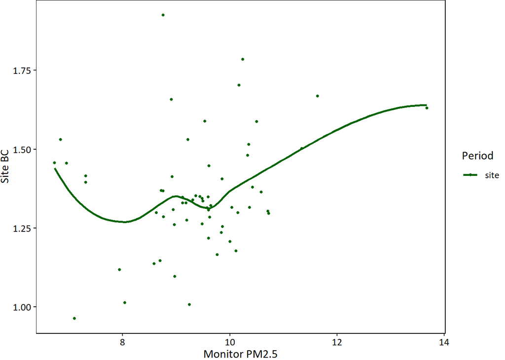

3. Site BC and monitor temperature (mean of closest 3 monitors to the sampling location)

The correlation coefficient for average site BC to average monitor temperature is -0.78.

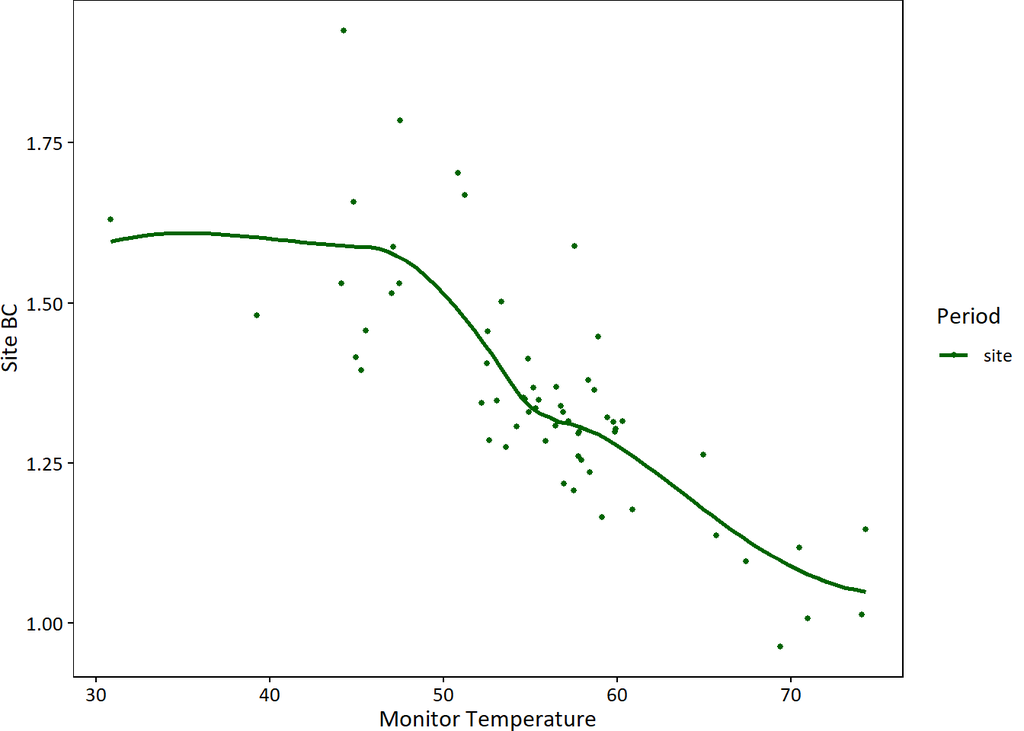

### C) Weekly and monthly relationships between filter BC and spatiotemporal predictors

1. Filter BC and monitor BC by week and month

The correlation coefficients for weekly filter BC-monitor BC and monthly filter BC-monitor BC are 0.30 and 0.37, respectively.

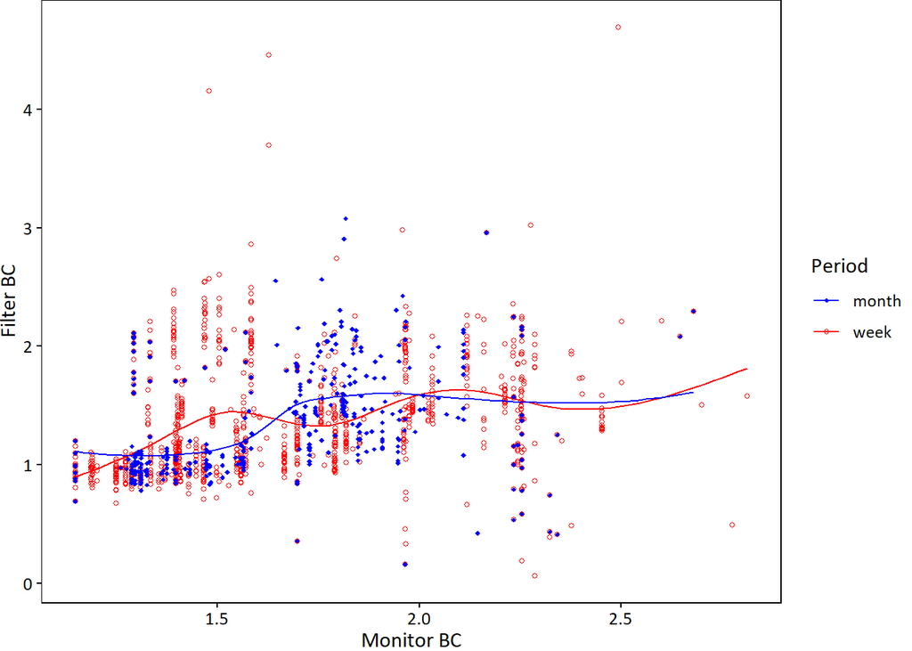

2. Filter BC and monitor PM (mean of closest 3 monitors to the filter location) by week and month

The correlation coefficients for weekly filter BC-monitor PM2.5 and monthly filter BC-monitor PM2.5 are 0.09 and 0.13, respectively.

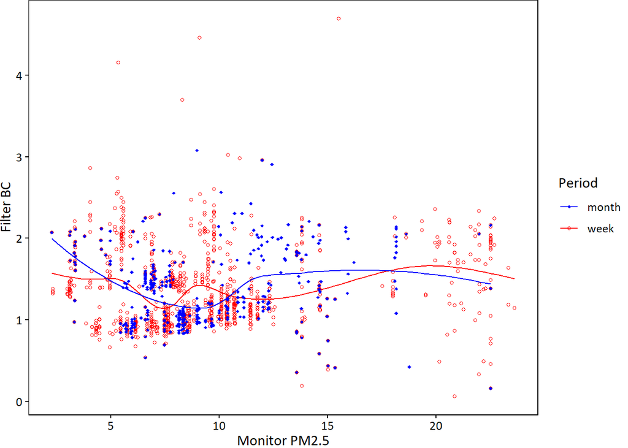

3. Filter BC and monitor temperature (mean of closest 3 monitors to the filter location) by week and month

The correlation coefficients for weekly filter BC-monitor temperature and monthly filter BC-monitor temperature are -0.64 and -0.67, respectively.

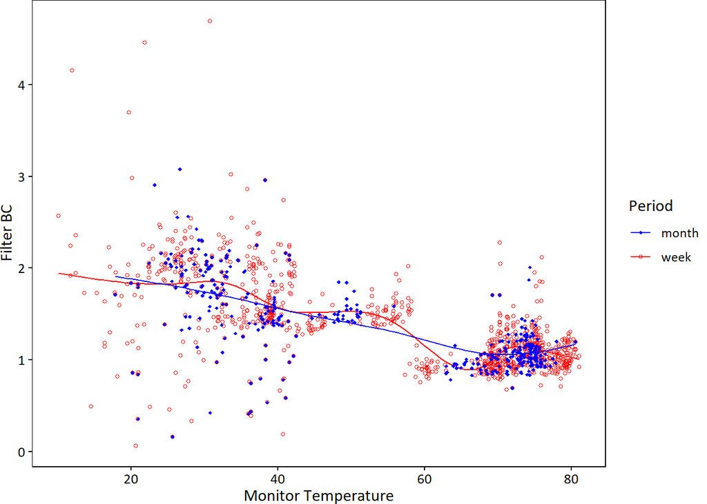

### D) Charaterizing spatial and temporal variability

1. What is the distribution of coefficient of variation (CV) values for each sampling location?

Some sites have a large amount of variability (CV > 0.25) in weekly BC concentrations measured across the study period. This could be a challenge, since it implies the spatial patterns aren’t consistent throughout the year

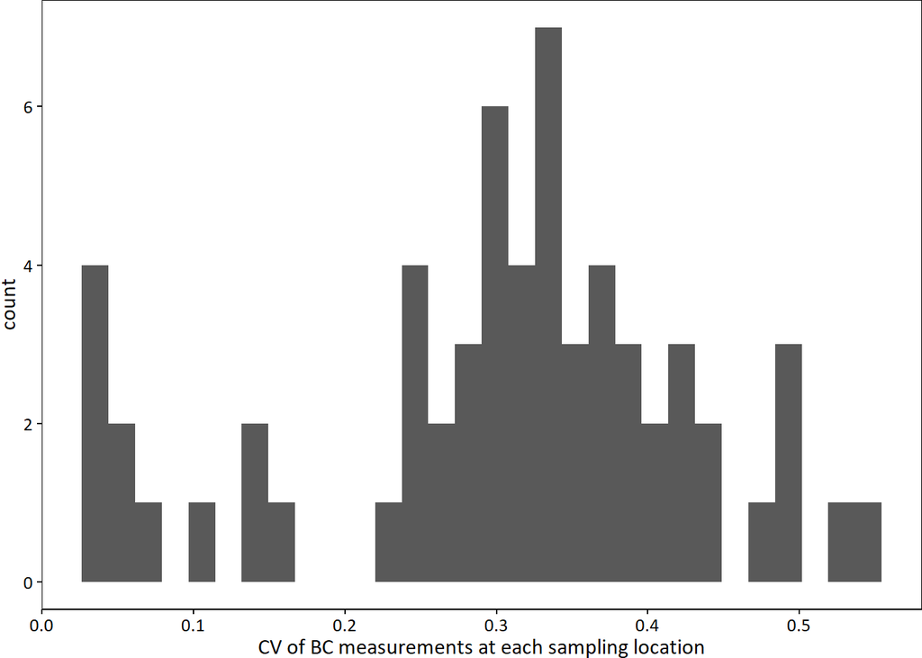

### E) Spatial patterns of BC

Our sampling locations cover the entire Denver metro area within the 470 loop.

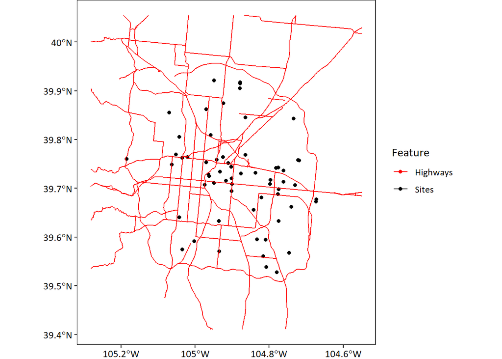

1. Surface (IDW) based on average BC at each sampling site (entire study period)

```
## [inverse distance weighted interpolation]
```

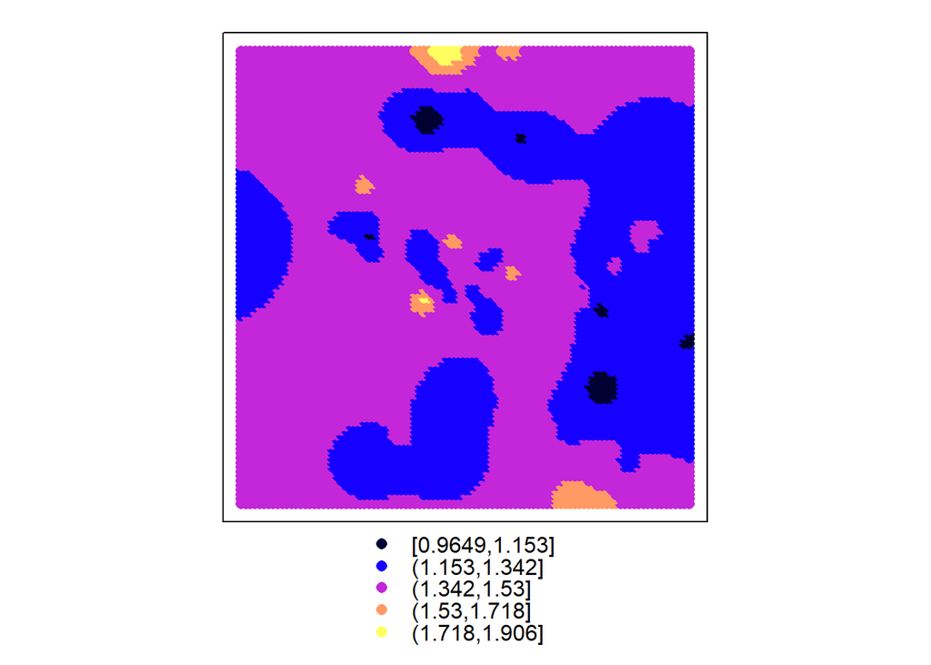

2. Surfaces (IDW) based on monthly average BC at each sampling site

May, 2018

```
## [inverse distance weighted interpolation]
```

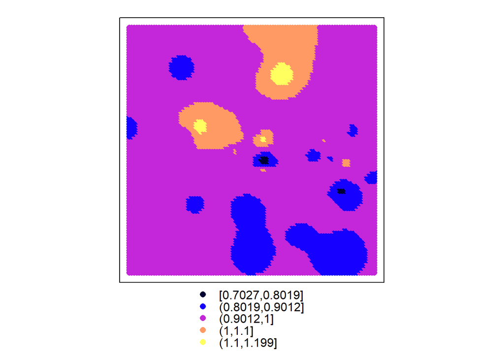

June, 2018

```
## [inverse distance weighted interpolation]
```

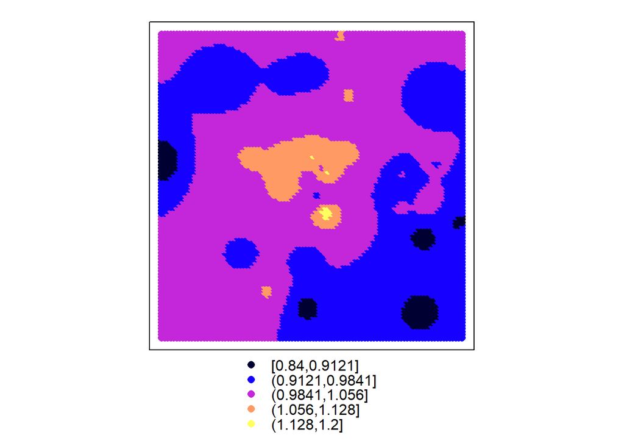

July, 2018

```
## [inverse distance weighted interpolation]
```

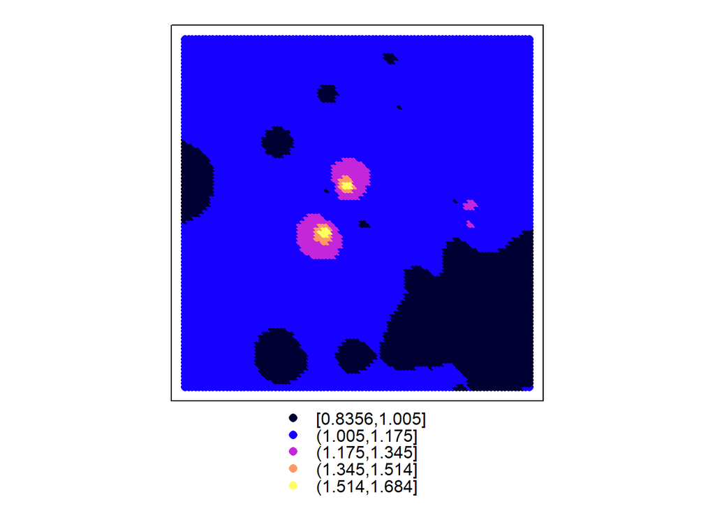

August, 2018

```
## [inverse distance weighted interpolation]
```

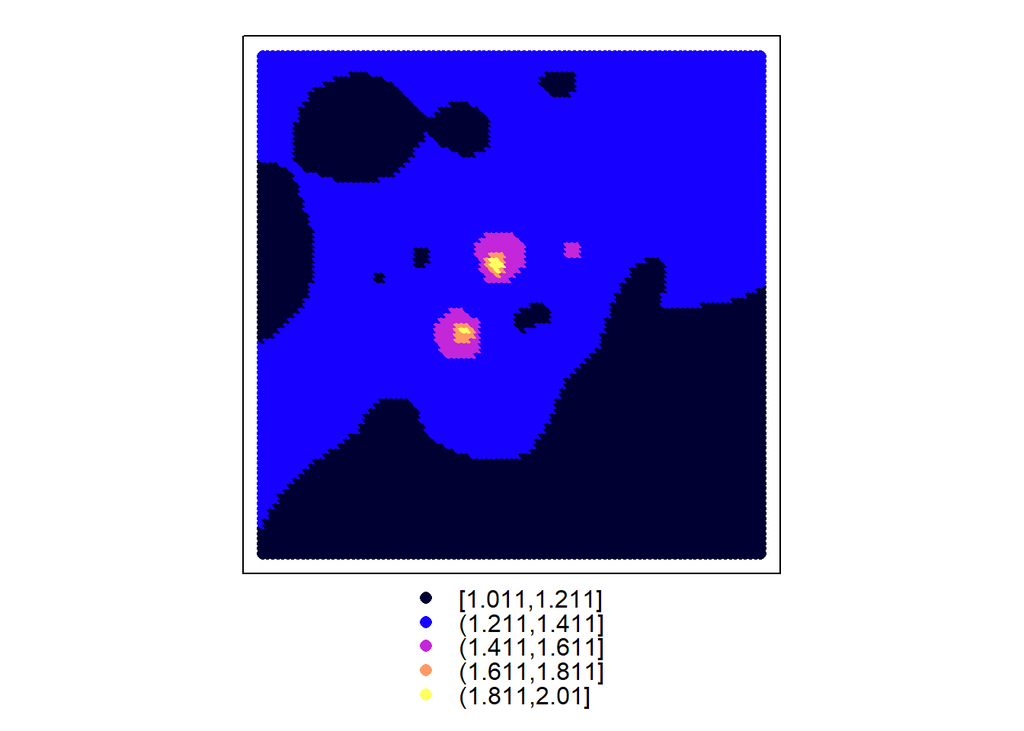

October, 2018

```
## [inverse distance weighted interpolation]
```

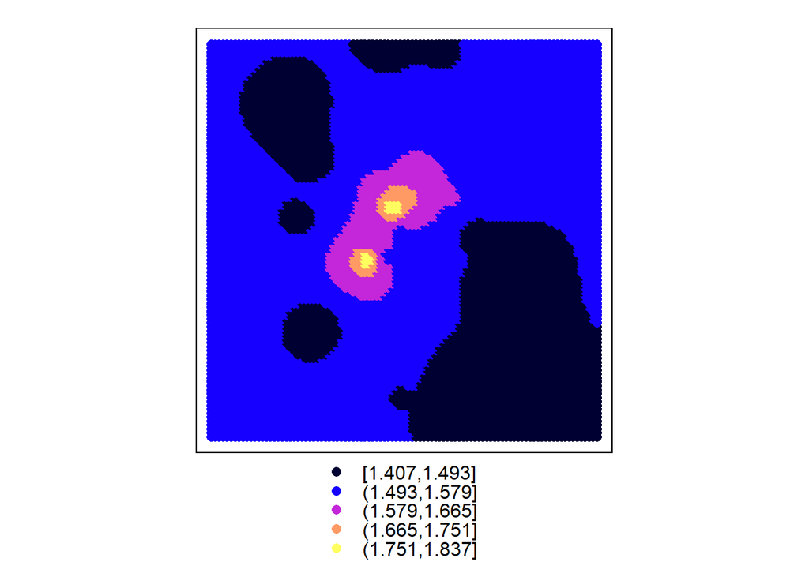

November, 2018

```
## [inverse distance weighted interpolation]
```

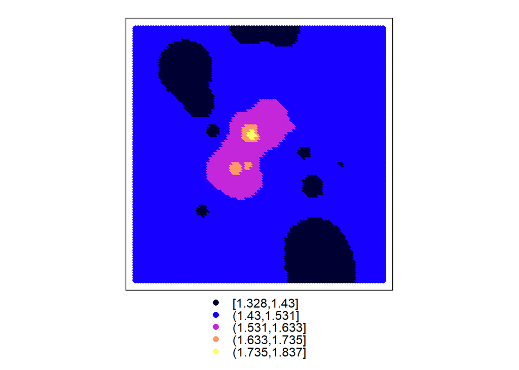

January, 2019

```
## [inverse distance weighted interpolation]
```

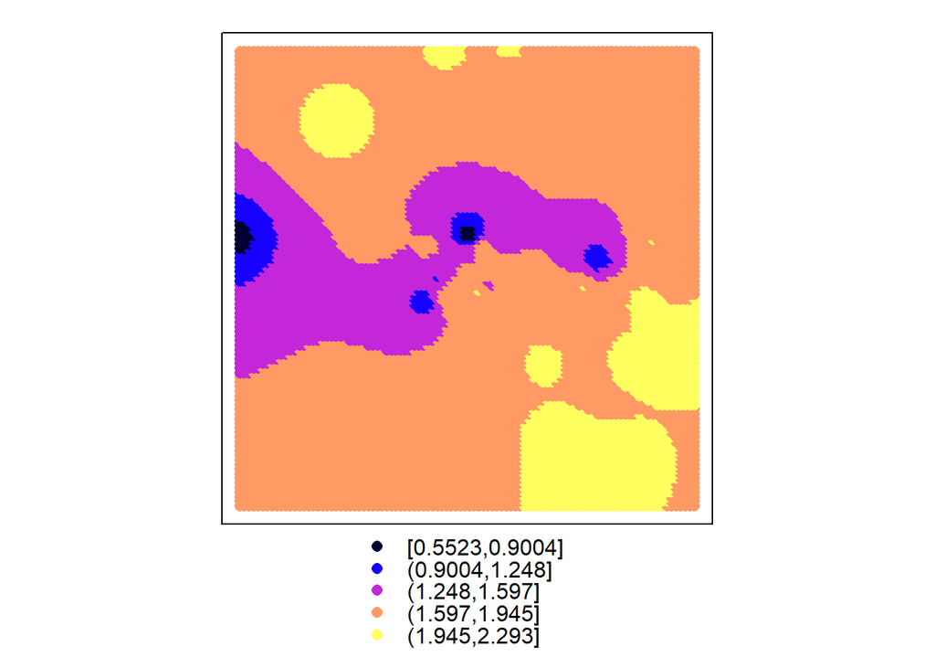

February, 2019

```
## [inverse distance weighted interpolation]
```

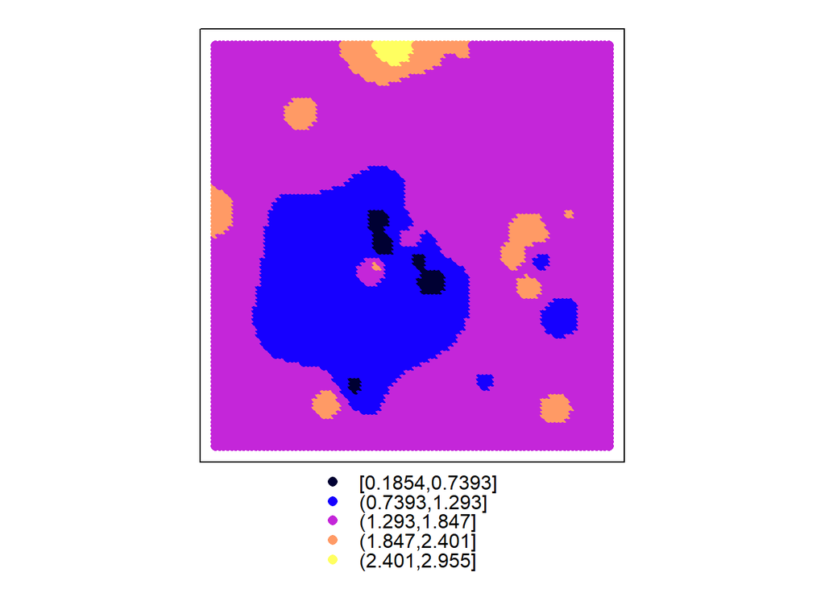

March, 2019

```
## [inverse distance weighted interpolation]
```

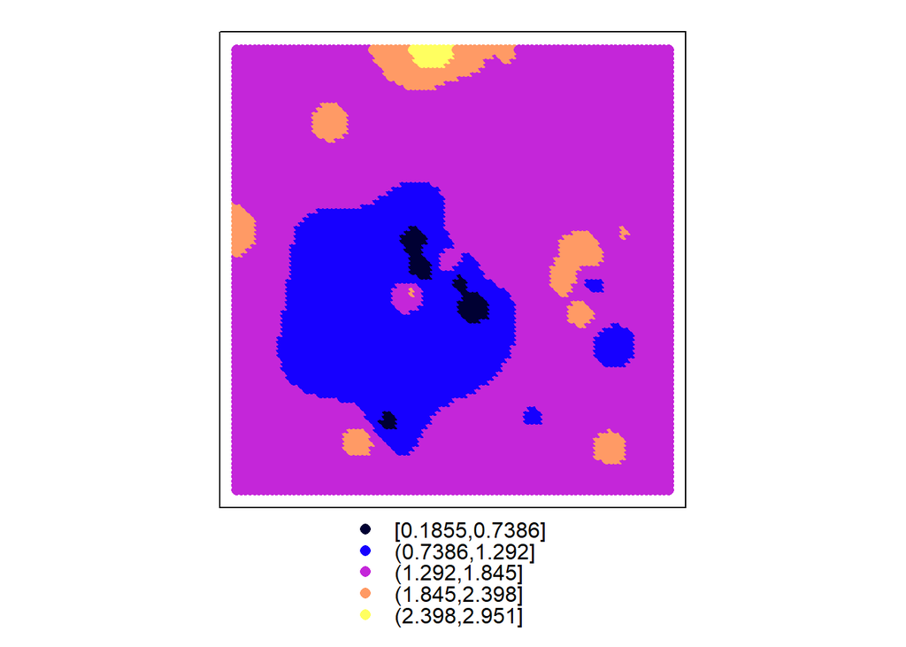